# BIOS 611 HW3 Exploratory Analysis, tibbles, and data import (Chapters 7, 10, and 11.2)

# Exercise 5

1. Instead of summarising the conditional distribution with a boxplot, you could use a frequency polygon. What do you need to consider when using `cut_width()` vs `cut_number()`? How does that impact a visualisation of the 2d distribution of `carat` and `price`?

   Answer: `cut_width()` vs `cut_number()`: This two functions choose how the polygon are devided. AKA, how do you decide the grouping. I think maybe you want to have a lower `cut_number()`? See below

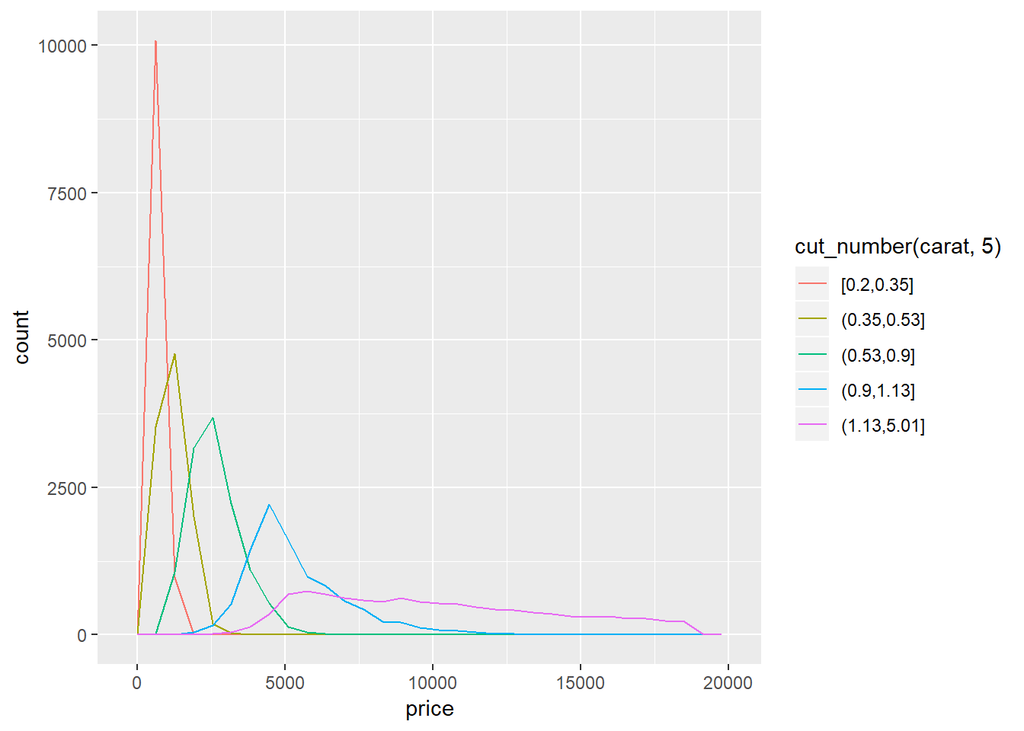

   ```r
   ggplot(data = diamonds,
      mapping = aes(color = cut_number(carat, 5), x = price)) +
     geom_freqpoly()
   ```

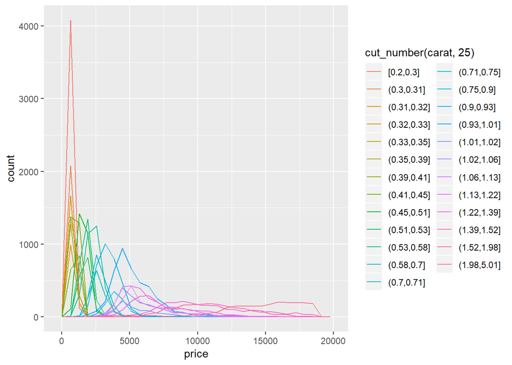

```r
ggplot(data = diamonds,
       mapping = aes(color = cut_number(carat, 25), x = price)) +
  geom_freqpoly()
```

If you create so many groups (cuts), then your plot will become really messy whn the dataset is really large. So you’d better cohose a smaller cut numbers.

2. Visualise the distribution of carat, partitioned by price. (Hint: consider a boxplot)

   Answer:

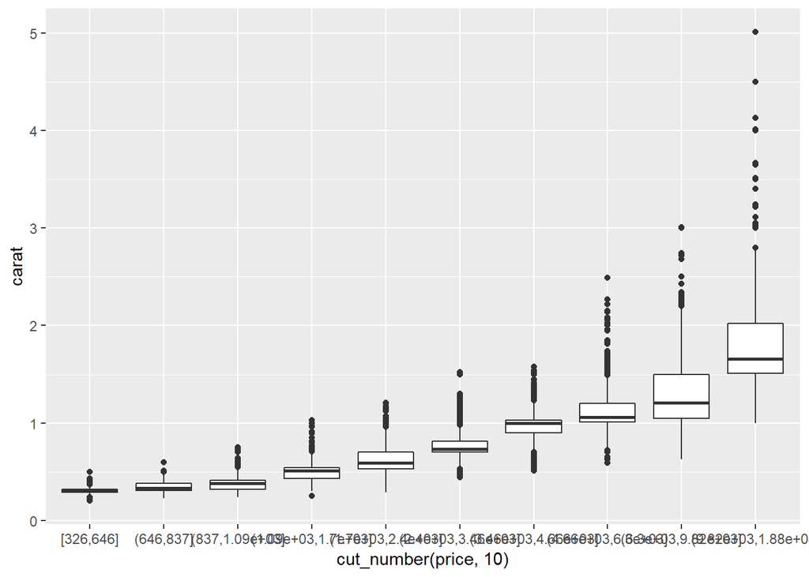

   ```r
   ggplot(diamonds, aes(x = cut_number(price, 10), y = carat)) +
     geom_boxplot()
   ```

3. How does the price distribution of very large diamonds compare to small diamonds? Is it as you expect, or does it surprise you? (Hint: Assuming you want to do a linear regression, is there any violation?)

   Answer:

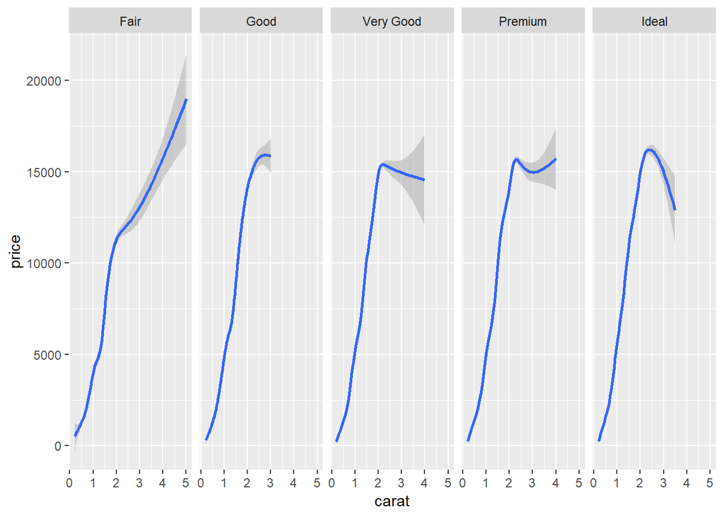

   ```r
   ggplot(diamonds,aes(x = carat, y = price))+
     geom_smooth()+
     facet_grid(.~cut)
   ```

5. Two dimensional plots reveal outliers that are not visible in one dimensional plots. For example, some points in the plot below have an unusual combination of `x` and `y` values, which makes the points outliers even though their `x` and `y` values appear normal when examined separately.

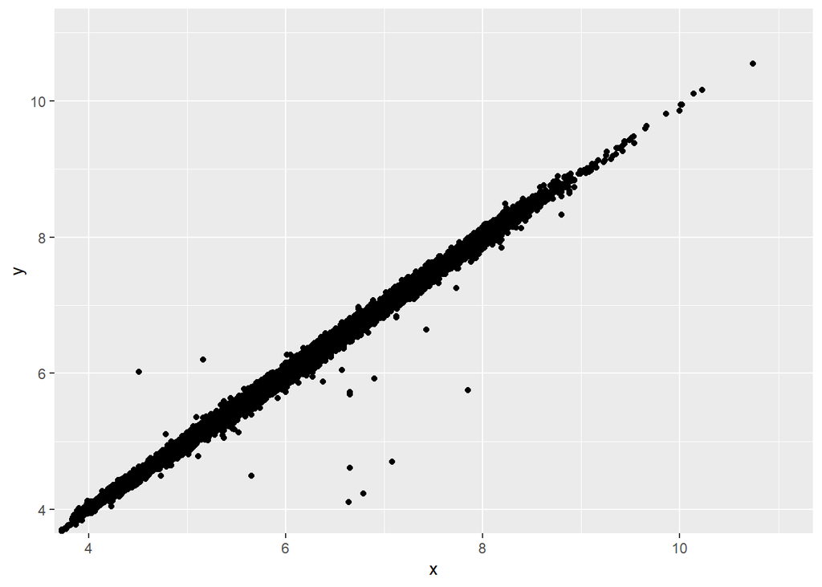

   ```r
   ggplot(data = diamonds) +
     geom_point(mapping = aes(x = x, y = y)) +
     coord_cartesian(xlim = c(4, 11), ylim = c(4, 11))
   ```

   Why is a scatterplot a better display than a binned plot for this case?

   Answer: I think the reason behind that is that the relationship is so easy to see and the outliers are not really too far away from ‘normal’ observation. So you may not be able to identify them correctly if ou use a binned plot!

# Exercise 6

1. Compare and contrast the following operations on a `data.frame` and equivalent tibble. What is different? Why might the default data frame behaviours cause you frustration?

   ```r
   df <- data.frame(abc = 1, xyz = "a")
   df$x
   df[, "xyz"]
   df[, c("abc", "xyz")]
   ```

   Answer: If you use df$x, it will auto-complete to be calling df$xyz. This is good, but when you have multiple similar variables, you are not happy. If you use a tibble, you won’t run into this problem as you do not have x as your columns.
2. If you have the name of a variable stored in an object, e.g. `var <- "mpg"`, how can you extract the reference variable from a tibble? For example, you simply could have done `mtcars$mpg`. But later on if you want to extract other variables as well, say `cyl`, which is given as an object `var`, you don’t want to manually put the variable names by typing `mtcars$cyl`. How would you do this without explicitly writing `"mpg"` or `"cyl"`?

   Answer: So I wil use the double bracket.

   ```r
   newdata <- as.tibble(mtcars)
   var <- "mpg"
   newdata[[var]]
   ```

   ```
   ##  [1] 21.0 21.0 22.8 21.4 18.7 18.1 14.3 24.4 22.8 19.2 17.8 16.4 17.3 15.2
   ## [15] 10.4 10.4 14.7 32.4 30.4 33.9 21.5 15.5 15.2 13.3 19.2 27.3 26.0 30.4
   ## [29] 15.8 19.7 15.0 21.4
   ```

3. Practice referring to non-syntactic names in the following data frame by:

   ```r
    newdata = tibble(`1` = rnorm(1:5), `2` = `1` + runif(5))
   ```

   1. Extracting the variable called `1`.

   Answer:

   ```r
   newdata[["1"]]
   ```

   ```
   ## [1]  0.07730312 -0.29686864 -1.18324224  0.01129269  0.99160104
   ```

   2. Plotting a scatterplot of `1` vs `2`.

   Answer:

[figure not shown]

   ```r
   ggplot(newdata,aes(x = "1",y = "2"))+
        geom_abline()
   ```

   3. Creating a new column called `3` which is `2` divided by `1`.

   Answer:

   ```r
   newdata[["3"]] <- newdata$`2` / newdata$`1`
   ```

   4. Renaming the columns to `one`, `two` and `three`.

   Answer:

   ```r
   newdata = rename(newdata,one = `1`, two = `2`, three = `3`)
   ```

4. What does `tibble::enframe()` do? When might you use it?  
   (How can you simply generate a tibble of two vectors (1 2 3 … 26, a b c … z)?)

   Answer: It converts named vectors to a data frame with names and values

```r
enframe(letters)
```

```
## # A tibble: 26 x 2
##     name value
##    <int> <chr>
##  1     1 a
##  2     2 b
##  3     3 c
##  4     4 d
##  5     5 e
##  6     6 f
##  7     7 g
##  8     8 h
##  9     9 i
## 10    10 j
## # ... with 16 more rows
```

# Exercise 7

1. What function would you use to read a file where fields were separated with  
   “|”?

   Answer: I will use `read_delim()` and use `delim = "|"`.
2. If you want to read a file from the third line, how would you code using `read_csv()` or `read_tsv()`?

   Answer: I will use the argument `skip = 2`.
3. Sometimes strings in a CSV file contain commas. To prevent them from causing problems they need to be surrounded by a quoting character, like `"` or `'`. By convention, `read_csv()` assumes that the quoting character will be `"`, and if you want to change it you’ll need to use `read_delim()` instead. What arguments do you need to specify to read the following text into a data frame? (Hint: Sometimes special characters act as a wild card. e.g. `.` represents any charaters, `*` stands for repetition, and so on. So, in order for R to recognize special characters as they are not as a wild card, we need to put a back-slash `\` in front of the character. e.g. `\.` does not mean everything, but it means `.`)

   ```r
   "x,y\n1,'a,b'"
   ```

   Answer: I think now, the `read_csv()` function has the quote argument which specify the quote.
4. Identify what is wrong with each of the following inline CSV files. What happens when you run the code?

   ```r
   read_csv("a,b\n1,2,3\n4,5,6")
   read_csv("a,b,c\n1,2\n1,2,3,4")
   read_csv("a,b\n\"1")
   ```

For 1, two columns are specified but there are three columns in the data, so the last one is being dropped.

For 2, the dimension is really tricky. The code specifies three columns, but the first one has only 2 and the second line has 4. So for the first line, `NA` is produced and the last number of the second line is being dropped.

For 3, We specified there are two columns, while we only have one data. So the `NA` is produced for the second column.